# Darwin’s data

## Reference for the solution(s)

A.C. Davison (2003) Statistical Models. Cambridge University Press. Examples 1.1, 3.11, 3.16, 7.24, 7.28, 8.13, 8.19

## Galton’s model

Galton assumed a model where the height of a self-fertilized plant is
$$Y = \mu + \sigma \varepsilon$$
and of a cross-fertilized plant is
$$X = \mu + \theta + \sigma \epsilon$$
where $\mu$, $\theta$ and $\sigma$ are unknown parameters, and $\varepsilon$ and $\epsilon$ are independent random variables with mean zero and unit variance.

Observations from self-fertilized plants $Y_1,\ldots,Y_{15}$ are i.i.d. as $Y$, and observations from cross-fertilized plants $X_1,\ldots,X_{15}$ are i.i.d. as $X$.

The comparison between two independent samples are usually visualized by a boxplot:

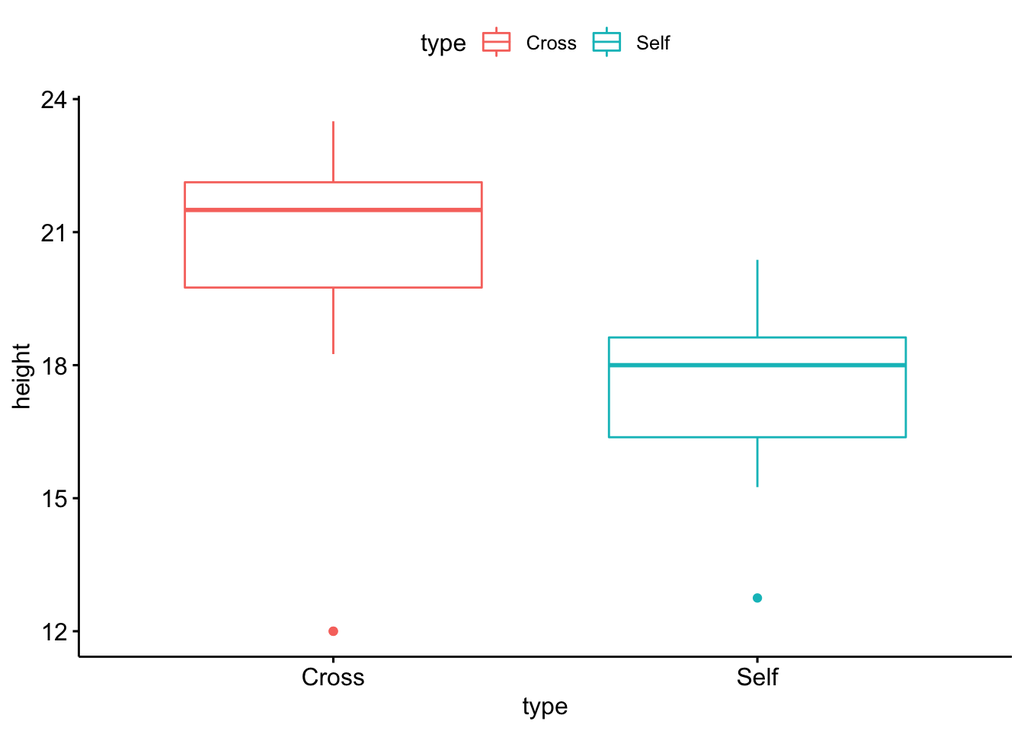

```r
library(ggpubr)
ggboxplot(darwin, x = "type", y = "height",color = "type")
```

If we assume that $\epsilon_i$ and $\varepsilon_i$ have a $N(0,1)$ distribution, we can use a two-sample t test

```r
t.test(height  ~ type, data=darwin, var.equal=TRUE)
```

```
    Two Sample t-test

data:  height by type
t = 2.4371, df = 28, p-value = 0.02141
alternative hypothesis: true difference in means is not equal to 0
95 percent confidence interval:
 0.4173433 4.8159900
sample estimates:
mean in group Cross  mean in group Self
           20.19167            17.57500
```

From the two-sample t test we obtain a point estimate of $\hat{\theta}=20.19-17.57= 2.62$ along with a 95% confidence interval $(0.417, 4.816)$ not including 0. The answer to Q1 is there is a significant height increase - estimated on average 2.62 eighths of an inch for cross-fertilized plants - and we reject $H_0:\theta=0$ with $p$-value $= 0.021$ (two-sided alternative). The answer to Q2 is that the average height increase is between $(0.417, 4.816)$ with 95% confidence.

Alternatives: Welch’s test

```r
t.test(height  ~ type, data=darwin)
```

```
    Welch Two Sample t-test

data:  height by type
t = 2.4371, df = 22.164, p-value = 0.02328
alternative hypothesis: true difference in means is not equal to 0
95 percent confidence interval:
 0.3909566 4.8423767
sample estimates:
mean in group Cross  mean in group Self
           20.19167            17.57500
```

or by including pot’s effect

```r
summary(lm(height  ~ 0 + pot + type, data=darwin))
```

```
Call:
lm(formula = height ~ 0 + pot + type, data = darwin)

Residuals:
    Min      1Q  Median      3Q     Max
-8.3500 -1.1596  0.4667  1.7216  3.8948

Coefficients:
         Estimate Std. Error t value Pr(>|t|)
potI       20.350      1.343  15.147 4.21e-14 ***
potII      21.246      1.343  15.814 1.58e-14 ***
potIII     20.333      1.097  18.536 4.03e-16 ***
potIV      19.105      1.195  15.983 1.24e-14 ***
typeSelf   -2.617      1.097  -2.385    0.025 *
---
Signif. codes:  0 '***' 0.001 '**' 0.01 '*' 0.05 '.' 0.1 ' ' 1

Residual standard error: 3.004 on 25 degrees of freedom
Multiple R-squared:  0.9795,    Adjusted R-squared:  0.9754
F-statistic: 238.6 on 5 and 25 DF,  p-value: < 2.2e-16
```

## Fisher’s model

In order to minimize differences in humidity, growing conditions, and lighting, Darwin had taken the trouble to plant the seeds in pairs in the same pots.

Fisher considered the model
$$Y_i = \mu_i + \sigma \varepsilon_{i}, \quad X_i = \mu_i + \theta + \sigma \epsilon_{i}, \quad i = 1,\ldots,n$$

The parameter $\mu_i$ represents the effects of the planting conditions for the $i$th pair, and $\varepsilon_i$ and $\epsilon_i$ are independent random variables with mean zero and unit variance.

The $\mu_i$ could be eliminated by using the differences
$$D_i = X_i - Y_i$$
which have mean $\theta$ and variance $2\sigma^2$.

The comparison within pairs can be visualized by the following plot:

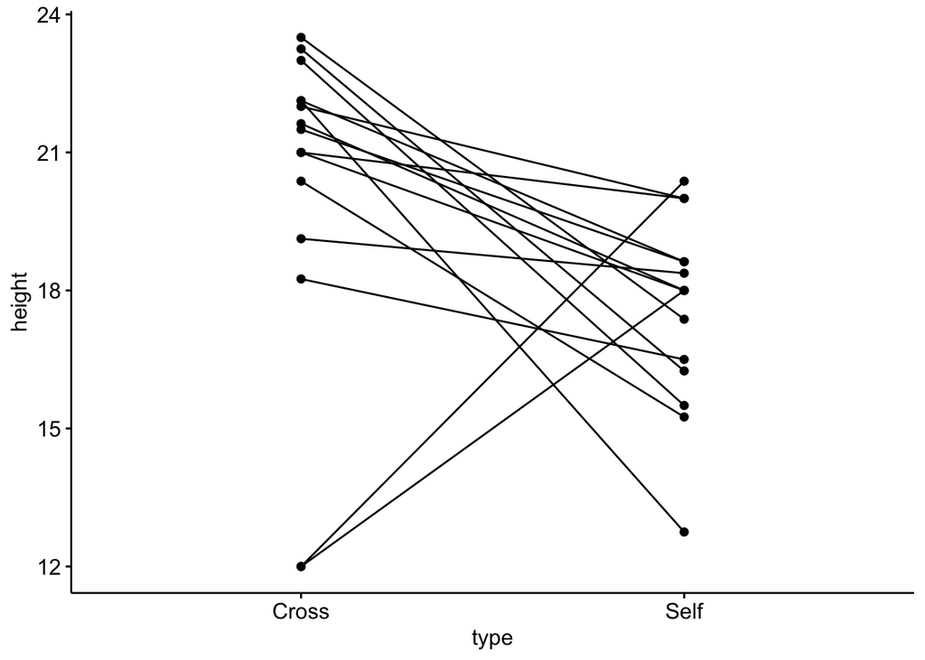

```r
ggline(darwin, x = "type", y = "height", group="pair")
```

```r
differences <- apply(darwin_pair[,3:2],1,diff)
t.test(differences)
```

```
    One Sample t-test

data:  differences
t = 2.148, df = 14, p-value = 0.0497
alternative hypothesis: true mean is not equal to 0
95 percent confidence interval:
 0.003899165 5.229434169
sample estimates:
mean of x
 2.616667
```

As an alternative: consider the analysis of variance with, in order: no differences among pairs and no difference between cross-fertilization and self-fertilization; no differences among pairs but an effect of fertilization type; differences among the pots and an effect of fertilization type; and differences among the pots and among the pairs and an effect of fertilization type:

```r
summary(aov(lm(height ~ type + pot +  pair, darwin)))
```

```
            Df Sum Sq Mean Sq F value Pr(>F)
type         1  51.35   51.35   4.614 0.0497 *
pot          3  16.46    5.49   0.493 0.6928
pair        11  69.80    6.35   0.570 0.8230
Residuals   14 155.82   11.13
---
Signif. codes:  0 '***' 0.001 '**' 0.01 '*' 0.05 '.' 0.1 ' ' 1
```

## Distribution-free model

Consider a more general matched pair model for the Darwin data:
$$Y_i = \mu_i + \sigma_i\varepsilon_{i}, \quad X_i = \mu_i + \theta + \tau_i\epsilon_{i}, \quad i = 1,\ldots,n$$
with $\varepsilon_i$ and $\epsilon_i$ are independent random variables with continuous distribution and mean zero and unit variance.

The height differences may be written as
$$D_i = \theta + (\tau_i\epsilon_{i} - \sigma_i\varepsilon_{i})$$
Assume that $\varepsilon_{i}$ and $\epsilon_{i}$ are independent and symmetrically distributed around 0 ( e.g. Uniform$(-i,i)$ ), then $D_i$ is symmetrically distributed around $\theta$, i.e.
$$D_i - \theta \stackrel{d}{=} \theta - D_i \qquad i=1,\ldots,n$$

```r
binom.test(x=13, n=15, p=0.5, alternative="two.sided")
```

```
    Exact binomial test

data:  13 and 15
number of successes = 13, number of trials = 15, p-value = 0.007385
alternative hypothesis: true probability of success is not equal to 0.5
95 percent confidence interval:
 0.5953973 0.9834241
sample estimates:
probability of success
             0.8666667
```

The sign test provides significant evidence that $\theta\neq 0$ ($p$-value = 0.007385, two-sided alternative) with little assumptions. The probability for cross-fertilized plant of being higher than its self-fertilized counterpart is estimated $86\%$ with a 95% confidence interval of $(0.59, 0.98)$.